# Introduction to Python

> Getting Started with Python

Kuo, Yao-Jen from [DATAINPOINT](https://www.datainpoint.com/)

## TL; DR

> In this lecture, we will talk about the fundamentals of Python from operators, variables, and types to conditionals.

## The What and Why

## Why do we want to learn Python?

Simply put, to tackle the modern data science applications.

## What is modern data science?

> Modern data science is a huge field, it invovles applications and tools like importing, tidying, transformation, visualization, modeling, and communication. Surrounding all these is programming.

[figure not shown]

Source: [R for Data Science](https://r4ds.had.co.nz/)

## Apparently, Python is gonna be our choice of "Program".

## The sarcastic ones

[figure not shown]

Source: https://twitter.com/cdixon/status/428914681911070720/photo/1

## The serious ones

[figure not shown]

Source: http://drewconway.com/

## What is Python? the Monty Python British surreal comedy troupe

[figure not shown]

Source: https://giphy.com/

## Python: the programming language

> Python is a clear and powerful object-oriented programming language.

Source: https://www.python.org/

## Python: the gigantic snake and its relatives

- Python: the programming language itself
- Anaconda: the data science total solution
- Reticulate: the Python and R interface package

## Python is a general-purposed language that is extremely powerful and popular among many applications

- Automation
- Databases
- Analytics
- Graphical user interfaces
- Machine learning
- Web frameworks
- Web scraping
- ...etc.

## How does Python do that?

Simply put: third party libraries.

## What is a third party library?

A third party library refers to any library where the latest version of the code is not maintained and hosted by neither ourselves nor the official organization, say [Python.org](https://www.python.org/).

## So which third party library makes Python the go-to choice for data science?

- NumPy
- Pandas
- Matplotlib
- Scikit-Learn
- TensorFlow
- PyTorch
- ...etc.

## Why Python?

Let's review 2 questions in [2019 Kaggle ML & DS Survey](https://www.kaggle.com/c/kaggle-survey-2019)

- Q18: What programming languages do you use on a regular basis?
- Q19: What programming language would you recommend an aspiring data scientist to learn first?

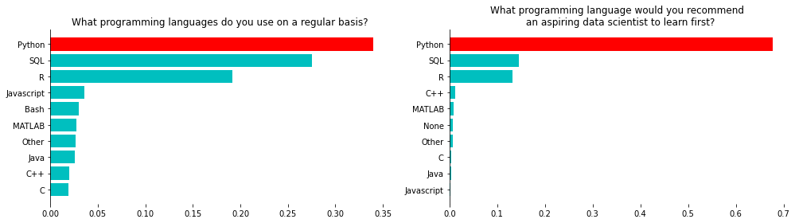

```python
# What programming languages do you use on a regular basis?
# What programming language would you recommend an aspiring data scientist to learn first?
plot_ans_18_19(ans_18, ans_19)
```

## Let's not only explore a snapshot, but also the trend on [Stack Overflow](https://stackoverflow.com/)

## What is [Stack Overflow](https://stackoverflow.com/)?

> Stack Overflow is the largest, most trusted online community for developers to learn, share their programming knowledge, and build their careers.

## Trust me, you will love [Stack Overflow](https://stackoverflow.com/) so much in the future, short and long-term

## We love it SO MUCH, someone even writes a book for it!

[figure not shown]

Source: Google Search

## Python is growing so fast in the developer community in the last 10 years

[Stack Overflow Trends](https://insights.stackoverflow.com/trends?tags=java%2Cc%2Cc%2B%2B%2Cpython%2Cc%23%2Cvb.net%2Cjavascript%2Cassembly%2Cphp%2Cperl%2Cruby%2Cswift%2Cr%2Cobjective-c)

[figure not shown]

## How to utilize [Stack Overflow](https://stackoverflow.com/)?

- The first post is question itself
- The second post, if checked "Green", is the answer chose by the initiatior
- The third post, is the answer upvoted by others

## Setting up a Python Development Environment

## Given Python is a general-purposed programming language, there are variuos ways setting up a Python development environement

## It is a mix-and-match challenge

- The operating system
- The Python interpreter
- The Integrated Development Environment
- The package/environment manager

## Even among data analysts, everyone has its own favorite flavour

[figure not shown]

Source: https://giphy.com/

## The best practice so far for a data analyst is Python interpreter + Jupyter

## For those who has no prior experience with Python

Log in our pre-configured [JupyterHub](https://lab.datainpoint.com/) in browser with your own [GitHub](https://github.com/) account.

## When you are more familiar with Python, learn advanced topics then choose your own flavour

- Path variables
- Library management
- Virtual environemnt
- Deployment

## What is a program?

> A program is a sequence of instructions that specifies how to perform a computation. The computation might be something mathematical, such as solving a system of equations, something symbolic, such as searching for and replacing text in a document, or something graphical, like processing an image.

Source: [Think Julia: How to Think Like a Computer Scientist](https://benlauwens.github.io/ThinkJulia.jl/latest/book.html)

## Critical elements of writing/running a Python program

- Text editor
- Python interpreter
- Terminal
- Integrated development environment(IDE)

## At the homepage of your Jupyter Notebook Server

- New > Text File
- New > Terminal
- New > Notebook

## A few Python programs to try on first

- Hello world!
- Hello John Doe!
- The Zen of Python

## Hello world!

```python
print("Hello, world!")
```

```
Hello, world!
```

## Hello John Doe!

"John Doe" (for males) and "Jane Doe" (for females) are multiple-use names that are used when the true name of a person is unknown or is being intentionally concealed.

Source: https://en.wikipedia.org/wiki/John_Doe

```python
john_doe = input("Please input your name:")
print("Hello, {}!".format(john_doe))
```

```
Please input your name:Tony Kuo
Hello, Tony Kuo!
```

## Zen of Python

Long time Pythoneer Tim Peters) succinctly channels the BDFL's guiding principles for Python's design into 20 aphorisms, only 19 of which have been written down.

```python
import this
```

```
The Zen of Python, by Tim Peters

Beautiful is better than ugly.
Explicit is better than implicit.
Simple is better than complex.
Complex is better than complicated.
Flat is better than nested.
Sparse is better than dense.
Readability counts.
Special cases aren't special enough to break the rules.
Although practicality beats purity.
Errors should never pass silently.
Unless explicitly silenced.
In the face of ambiguity, refuse the temptation to guess.
There should be one-- and preferably only one --obvious way to do it.
Although that way may not be obvious at first unless you're Dutch.
Now is better than never.
Although never is often better than *right* now.
If the implementation is hard to explain, it's a bad idea.
If the implementation is easy to explain, it may be a good idea.
Namespaces are one honking great idea -- let's do more of those!
```

## My favorite one would be:

> Now is better than never.

How about yours?

## Functions

## What are `print()` and `input()` in our previous examples?

`print()` and `input()` are so-called **built-in** functions in Python.

## What is a function

> A function is a named sequence of statements that performs a computation, either mathematical, symbolic, or graphical. When we define a function, we specify the name and the sequence of statements. Later, we can call the function by name.

## How do we analyze a function?

- function name
- inputs and arguments, if any
- sequence of statements
- outpus, if any

## Take bubble tea shop for instance

[figure not shown]

Source: Google Search

## What is a built-in function?

> A pre-defined function, we can call the function by name without defining it.

## How many built-in functions are available for us?

- `print()`
- `input()`
- `help()`
- `type()`
- ...etc.

Source: https://docs.python.org/3/library/functions.html

## Get HELP with `help()`

```python
help(print)
```

```
Help on built-in function print in module builtins:

print(...)
    print(value, ..., sep=' ', end='\n', file=sys.stdout, flush=False)

    Prints the values to a stream, or to sys.stdout by default.
    Optional keyword arguments:
    file:  a file-like object (stream); defaults to the current sys.stdout.
    sep:   string inserted between values, default a space.
    end:   string appended after the last value, default a newline.
    flush: whether to forcibly flush the stream.
```

```python
help(input)
```

```
Help on method raw_input in module ipykernel.kernelbase:

raw_input(prompt='') method of ipykernel.ipkernel.IPythonKernel instance
    Forward raw_input to frontends

    Raises
    ------
    StdinNotImplentedError if active frontend doesn't support stdin.
```

```python
help(type)
```

```
Help on class type in module builtins:

class type(object)
 |  type(object_or_name, bases, dict)
 |  type(object) -> the object's type
 |  type(name, bases, dict) -> a new type
 |  Methods defined here:
 |  __call__(self, /, *args, **kwargs)
 |      Call self as a function.
 |  __delattr__(self, name, /)
 |      Implement delattr(self, name).
 |  __dir__(...)
 |      __dir__() -> list
 |      specialized __dir__ implementation for types
 |  __getattribute__(self, name, /)
 |      Return getattr(self, name).
 |  __init__(self, /, *args, **kwargs)
 |      Initialize self.  See help(type(self)) for accurate signature.
 |  __instancecheck__(...)
 |      __instancecheck__() -> bool
 |      check if an object is an instance
 |  __new__(*args, **kwargs)
 |      Create and return a new object.  See help(type) for accurate signature.
 |  __prepare__(...)
 |      __prepare__() -> dict
 |      used to create the namespace for the class statement
 |  __repr__(self, /)
 |      Return repr(self).
 |  __setattr__(self, name, value, /)
 |      Implement setattr(self, name, value).
 |  __sizeof__(...)
 |      __sizeof__() -> int
 |      return memory consumption of the type object
 |  __subclasscheck__(...)
 |      __subclasscheck__() -> bool
 |      check if a class is a subclass
 |  __subclasses__(...)
 |      __subclasses__() -> list of immediate subclasses
 |  mro(...)
 |      mro() -> list
 |      return a type's method resolution order
 |  ----------------------------------------------------------------------
 |  Data descriptors defined here:
 |  __abstractmethods__
 |  __dict__
 |  __text_signature__
 |  ----------------------------------------------------------------------
 |  Data and other attributes defined here:
 |  __base__ = <class 'object'>
 |      The most base type
 |  __bases__ = (<class 'object'>,)
 |  __basicsize__ = 864
 |  __dictoffset__ = 264
 |  __flags__ = 2148291584
 |  __itemsize__ = 40
 |  __mro__ = (<class 'type'>, <class 'object'>)
 |  __weakrefoffset__ = 368
```

## We can also `help()` on `help()`

```python
help(help)
```

```
Help on _Helper in module _sitebuiltins object:

class _Helper(builtins.object)
 |  Define the builtin 'help'.
 |  This is a wrapper around pydoc.help that provides a helpful message
 |  when 'help' is typed at the Python interactive prompt.
 |  Calling help() at the Python prompt starts an interactive help session.
 |  Calling help(thing) prints help for the python object 'thing'.
 |  Methods defined here:
 |  __call__(self, *args, **kwds)
 |      Call self as a function.
 |  __repr__(self)
 |      Return repr(self).
 |  ----------------------------------------------------------------------
 |  Data descriptors defined here:
 |  __dict__
 |      dictionary for instance variables (if defined)
 |  __weakref__
 |      list of weak references to the object (if defined)
```

## Arithmetic Operators in Python

## Symbols that represent computations

- `+`, `-`, `*`, `/` are quite straight-forward
- `**` for exponentiation
- `%` for remainder
- `//` for floor-divide

## When an expression contains more than one operator, the order of evaluation depends on the operator precedence

1. Parentheses have the highest precedence
2. Exponentiation has the next highest precedence
3. Multiplication and Division have higher precedence than Addition and Subtraction
4. Operators with the same precedence are evaluated from left to right

## Variables

## One of the most powerful features of a programming language is the ability to manipulate variables

A variable is a name that refers to a value.

## Choose names for our variables: don'ts

- Do not use built-in functions
- Cannot use keywords
- Cannot start with numbers

## If you accidentally replaced built-in function with variable, use `del` to release it

```python
print = 5566
print("Hello, world!")
```

```
---------------------------------------------------------------------------
TypeError                                 Traceback (most recent call last)
<ipython-input-12-55e8932a6551> in <module>
      1 print = 5566
----> 2 print("Hello, world!")

TypeError: 'int' object is not callable
```

```python
del print
print("Hello, world!")
```

```
Hello, world!
```

## Choose names for our variables: dos

- Use a lowercase single letter, word, or words
- Separate words with underscores to improve readability(so-called snake case)
- Be meaningful

## Using `#` to write comments in our program

Comments can appear on a line by itself, or at the end of a line.

```python
degree_f = 50
# turn fahrenheit into celsius
degree_c = (degree_f - 32) * 5/9
degree_c = (degree_f - 32) * 5/9 # turn fahrenheit into celsius
print(degree_c)
```

```
10.0
```

## Everything from `#` to the end of the line is ignored when executed

We can use [pythontutor.com](http://www.pythontutor.com/visualize.html#mode=edit) to explore the execution of our code.

## Common Data Types

## Values belong to different types, we commonly use

- `int` and `float` for computing
- `str` for symbolic
- `bool` for conditionals
- `None` for missing values

## Use `type` function to check the type of a certain value/variable

```python
print(type(5566))
print(type(42.195))
print(type("Hello, world!"))
print(type(True))
print(type(False))
print(type(None))
```

```
<class 'int'>
<class 'float'>
<class 'str'>
<class 'bool'>
<class 'bool'>
<class 'NoneType'>
```

## How to form a `str`?

Use paired `'`, `"`, or `"""` to embrace letters strung together.

```python
str_with_single_quotes = 'Hello, world!'
str_with_double_quotes = "Hello, world!"
str_with_triple_double_quotes = """Hello, world!"""
print(type(str_with_single_quotes))
print(type(str_with_double_quotes))
print(type(str_with_triple_double_quotes))
```

```
<class 'str'>
<class 'str'>
<class 'str'>
```

## If we have single/double quotes in `str` values

```python
mcd = 'I'm lovin' it!'
```

```
  File "<ipython-input-17-85a683c7c2bf>", line 1
    mcd = 'I'm lovin' it!'
             ^
SyntaxError: invalid syntax
```

## Use `\` to escape or paired `"` or paired `"""`

```python
mcd = 'I\'m lovin\' it!'
mcd = "I'm lovin' it!"
mcd = """I'm lovin' it!"""
```

## We've seen arithmetic operators for numeric values

How about those for `str` and `bool`?

## `str` type takes `+` and `*`

- `+` for concatenation
- `*` for repetition

```python
mcd = "I'm lovin' it!"
print(mcd)
print(mcd + mcd)
print(mcd * 3)
```

```
I'm lovin' it!
I'm lovin' it!I'm lovin' it!
I'm lovin' it!I'm lovin' it!I'm lovin' it!
```

## Format our `str` printings

- The `sprintf` way
- The `.format()` way
- The `f-string` way

## The `sprintf` way: uses `%` for string print with format

```python
my_name = "John Doe"
print("Hello, %s!" % (my_name))
```

```
Hello, John Doe!
```

## The `.format()` way: uses `{}` for string print with format

```python
my_name = "John Doe"
print("Hello, {}!".format(my_name))
```

```
Hello, John Doe!
```

## The `f-string` way: uses `{}` for string print with format

```python
my_name = "John Doe"
print(f"Hello, {my_name}!")
```

```
Hello, John Doe!
```

## I myself, am more of a `.format()` way guy

It can take both index and key-value besides order.

```python
print("{} {} is my favorite Friends character.".format("Phoebe", "Buffay")) # format with order
print("{1} {0} is my favorite Friends character.".format("Buffay", "Phoebe")) # format with index
# format with key-value
print("{first_name} {last_name} is my favorite Friends character.".format(last_name="Buffay", first_name="Phoebe"))
```

```
Phoebe Buffay is my favorite Friends character.
Phoebe Buffay is my favorite Friends character.
Phoebe Buffay is my favorite Friends character.
```

## How to form a `bool`?

- Use keywords `True` and `False` directly
- Use relational operators
- Use logical operators

## Use keywords `True` and `False` directly

```python
print(True)
print(type(True))
print(False)
print(type(False))
```

```
True
<class 'bool'>
False
<class 'bool'>
```

## Use relational operators

We have `==`, `!=`, `>`, `<`, `>=`, `<=`, `in`, `not in` as common relational operators to compare values.

```python
print(5566 == 5566.0)
print(5566 != 5566.0)
print('56' in '5566')
```

```
True
False
True
```

## Use logical operators

- We have `and`, `or`, `not` as common logical operators to manipulate `bool` type values
- Getting a `True` only if both sides of `and` are `True`
- Getting a `False` only if both sides of `or` are `False`

```python
print(True and True)  # get True only when both sides are True
print(True and False)
print(False and False)
print(True or True)
print(True or False)
print(False or False) # get a False only when both sides are False
# use of not is quite straight-forward
print(not True)
print(not False)
```

```
True
False
False
True
True
False
False
True
```

## `bool` is quite useful in programs in conditional execution, iteration, and filtering data

## Python has a special type, the `NoneType`, with a single value, None

- This is used to represent null values or nothingness
- It is not the same as `False`, or an empty string `''` or 0
- It can be used when we need to create a variable but don’t have an initial value for it

```python
a_none_type = None
print(type(a_none_type))
print(a_none_type == False)
print(a_none_type == '')
print(a_none_type == 0)
print(a_none_type == None)
```

```
<class 'NoneType'>
False
False
False
True
```

## Data types can be dynamically converted using functions

- `int()` for converting to `int`
- `float()` for converting to `float`
- `str()` for converting to `str`
- `bool()` for converting to `bool`

## Upcasting(to a supertype) are always allowed

```python
print(int(True))
print(float(1))
print(str(1.0))
```

```
1
1.0
1.0
```

## While downcasting(to a subtype) needs type check and our attention

```python
print(float('1.0'))
print(int('1'))
print(bool('False')) # ?
```

```
1.0
1
True
```

## Conditional execution

## Use `if` to perform conditional executions

- A condition is an expression that can be evaluated as `bool`
- Indentation is necessary since Python does not use curly braces for code blocks

```python
x = 5566
if x > 0:
    print("{} is positive.".format(x))
```

```
5566 is positive.
```

## Use `if` and `else` to perform alternative executions

Since the condition must be true or false, exactly one of the alternatives will run.

```python
x = -5566
if x > 0:
    print("{} is positive.".format(x))
else:
    print("{} is negative.".format(x))
```

```
-5566 is negative.
```

## Use `if`, `elif`, and `else` to perform chained conditionals

Adding `else` clause makes our conditionals collectively exhaustive.

```python
x = 0
if x > 0:
    print("{} is positive.".format(x))
elif x < 0:
    print("{} is negative.".format(x))
else:
    print("{} is neither positive nor negative.".format(x))
```

```
0 is neither positive nor negative.
```

## We can break down alternative/chained conditionals once our conditions are mutually exclusive

```python
x = 5566
if x > 0:
    print("{} is positive.".format(x))
if x < 0:
    print("{} is negative.".format(x))
if x == 0:
    print("{} is neither positive nor negative.".format(x))
```

```
5566 is positive.
```

## We can also nest conditionals within other conditionals

```python
x = 5566
if x > 0:
    print("{} is positive.".format(x))
else:
    if x < 0:
        print("{} is negative.".format(x))
    else:
        print("{} is neither positive nor negative.".format(x))
```

```
5566 is positive.
```

## If conditions are NOT mutually exclusive in a chained condition

- Still, exactly one of the alternatives will run
- But order matters

## Take the famous `FizzBuzz` for example

Fizz buzz (often spelled FizzBuzz in this context) has been used as an interview screening device for computer programmers. Writing a program to output the first 100 FizzBuzz numbers is a trivial problem for any would-be computer programmer, so interviewers can easily filter out those with insufficient programming ability.

Source: https://en.wikipedia.org/wiki/Fizz_buzz

```python
x = 15
if x % 15 == 0:
    print("Fizz Buzz")
elif x % 3 == 0:
    print("Fizz")
elif x % 5 == 0:
    print("Buzz")
```

```
Fizz Buzz
```